# Operator-Theoretic Foundations & Policy Gradient Methods for General MDPs

**Abhishek Gupta**

(joint work with **Prof. Aditya Mahajan** (McGill University))  
Associate Professor & Graduate Studies Chair, ECE  
Co-Director, IITB-OSU Frontier Center  
The Ohio State University  
Founder, Ensemble Control Inc.

## Increasing sensors + actuators + compute + interconnection

**Application agnostic foundational theory and algorithms**

## Foundational theory for decisions that scale

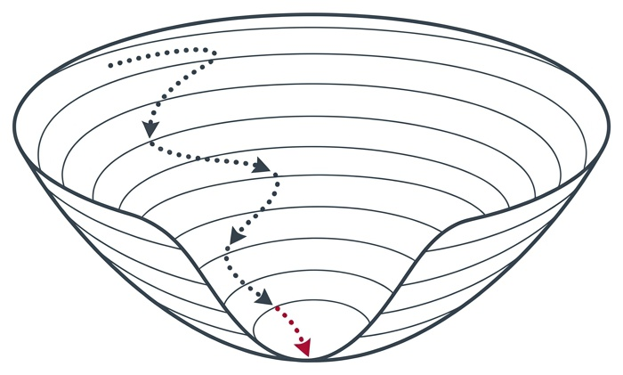

Theory

**Reinforcement Learning & Control:** New mathematical convergence techniques for infinite dimensional MDPs.

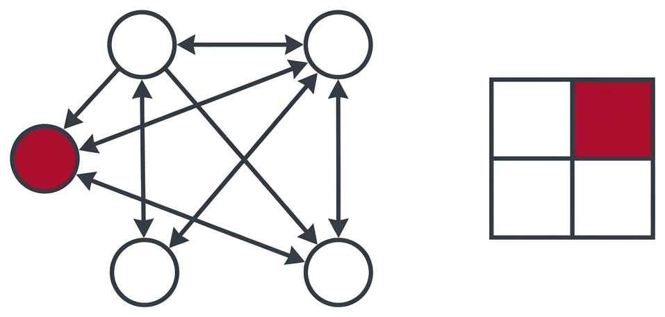

Theory

**Game Theory & Multi-Agent Systems:** Solution approaches for dynamic teams & games, incentive design problems, and bimatrix games.

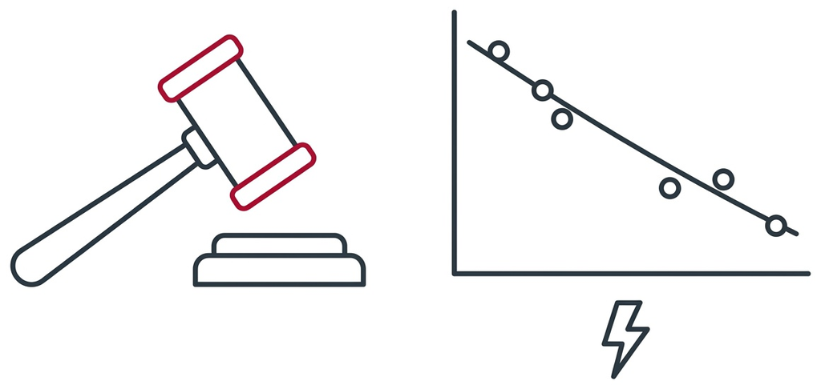

Theory

**Auctions, Mechanism Design & Pricing:** Truthful auctions and dynamic pricing for electricity and transportation markets.

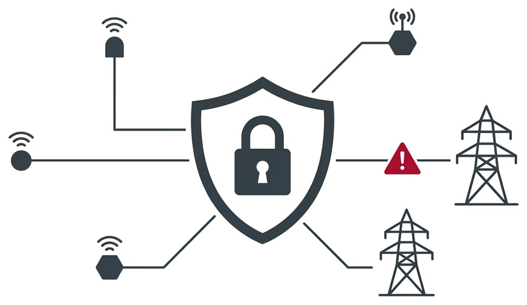

Application

**Cyberphysical Security:** Dynamic watermarking and model-free attack detection that protect networked systems from intelligent adversaries.

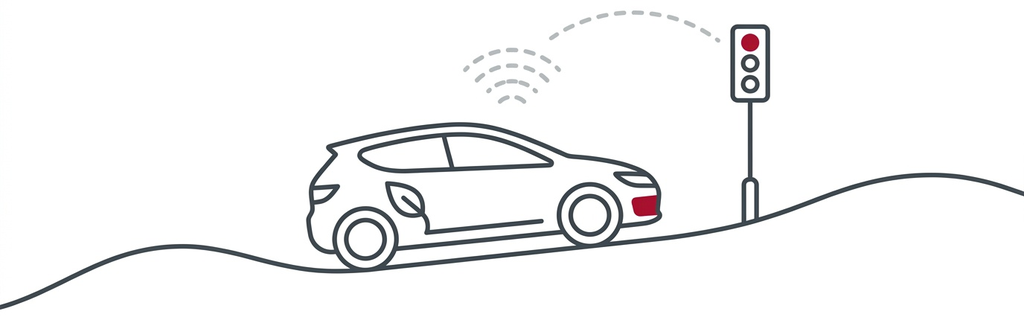

Application

**Transportation & Autonomy:** Deep RL, approximate DP, and parameter identification for eco-driving in connected hybrid electric vehicles.

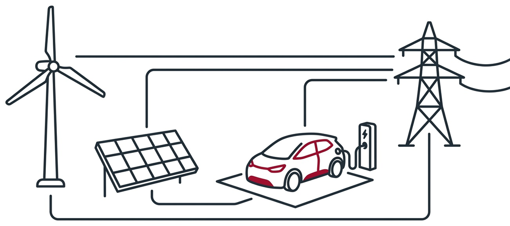

Application

**Energy Grids:** Market mechanisms and EV-charge scheduling algorithms for deep renewable integration.

**Also a serial “failed” entrepreneur**

## Modern Engineering Demands Control of Infinite-dimensional Systems

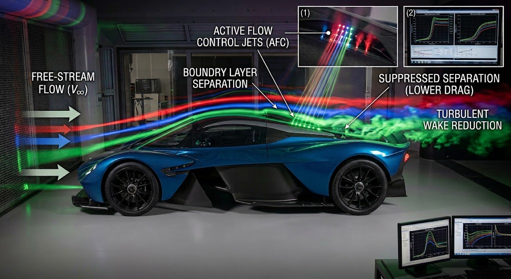

**Active flow control**: State is the fluid flow field around a body — an infinite-dimensional function space.

**Goal** is to reduce the aerodynamic drag and reduce cabin noise using actuators that manipulate the boundary layer.

## DFT based New Material Design

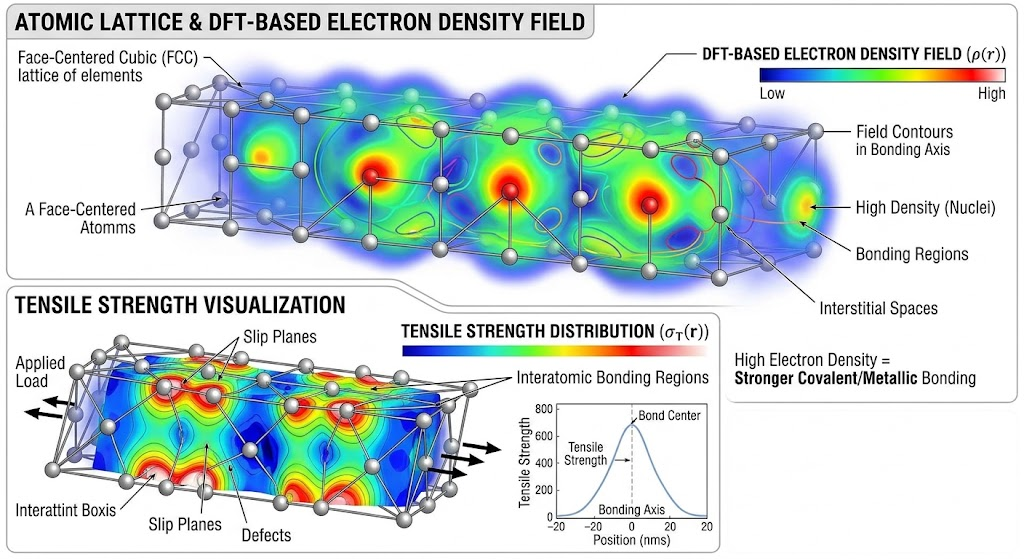

**New material discovery**: State is the electron density field in the lattice — an infinite-dimensional function space.

**Goal** is to search for continuous chemical composition and crystal structure spaces for target properties (critical temperatures ($T_c$) & electronic properties) using density functional theory.

## Solving Inverse Problems through Reinforcement Learning

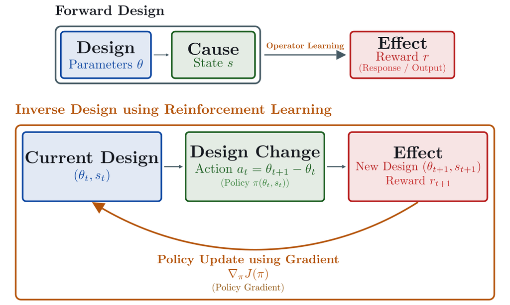

**Other Applications:**

- **Metamaterial & Photonic Design**: Finding continuous permittivity fields $\epsilon(\mathbf{x})$ to maximize target wave transmission (Maxwell PDEs).
- **Battery Fast Charging**: Designing charging current profiles $I(t)$ to minimize solid electrolyte interphase (SEI) growth & thermal degradation (Electrochemical PDEs).

## General MDPs: Formulation $(\mathcal S, \mathcal A, \mathcal K, \gamma, P, c, \rho)$

$\mathcal{S},\mathcal A$ are Polish, $\mathcal K\subset\mathcal S\times\mathcal A$ is measurable, and $\pi:s\mapsto\mathcal P(\mathcal K(s))$. Compute $\pi^*$ such that $J_{\pi^*}(\rho) \leq J_{\pi}(\rho)$:
$$\begin{align*}
J_{\pi}(\rho) = \langle v_{\pi}, \rho \rangle
\text{ where }
v_{\pi}(s_0)
= \mathop{\mathbb{E}}_{a_t\sim\pi(s_t)}\left[\sum_{t=0}^\infty \gamma^t c(s_t,a_t)\Big| s_0\right].
\end{align*}$$

The **Bellman operators** are defined as

$$\begin{align*}
[\boldsymbol{T} v](s) = \inf_{p \in \mathcal P(\mathcal K(s))} \int \left(c(s,a)+\gamma \int v(s') P(ds'|s,a)\right) p(da)\\
[\boldsymbol{T}_\pi v](s) = \int \left(c(s,a)+\gamma \int v(s') P(ds'|s,a)\right) \pi(da|s).
\end{align*}$$

Two widely used algorithms to compute $\pi^*$ iteratively are

- Value iteration: $v_{k+1} = \boldsymbol{T} v_k$ with $v_0 = 0$
- Policy iteration: $\pi_{k+1} = \mathop{\mathrm{\arg\min}}_{\pi} \left\langle \boldsymbol{T}_{\pi} v_{\pi_k},\rho \right\rangle$ with $\pi_0$ picked arbitrarily

> What about existence of $\pi^*$?

## Previous work on Existence Results

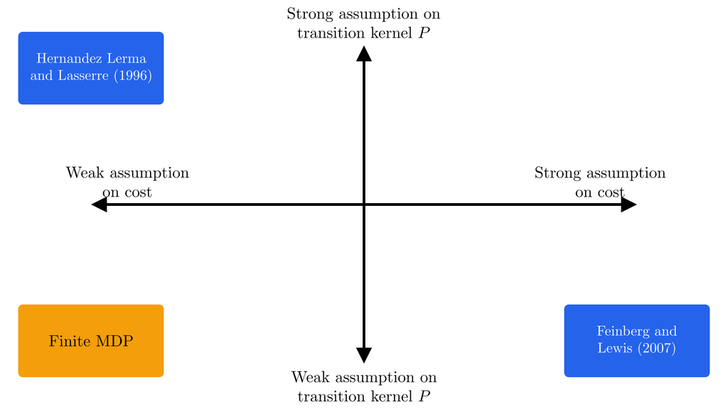

## Previous Work on Policy Gradient and RL Algorithms

**Current state of affairs**

- Finite MDPs: Watkins (1989), Borkar and Konda (1997), Haarnoja et. al. (2018)
- Finite MDPs with Function Approximation: Williams (1992), Mnih et. al. (2015), Schulman et. al. (2015), Schulman et. al. (2017)
- Continuous MDPs: Lillicrap et. al. (2015), Hafner et. al. (2023)

### Trouble with the current state of the affairs:

- **Extreme assumptions** for existence
- No exploitation of **structure** (monotonicity, Lipschitz continuity, invariance, LQG etc.)
- Using ad hoc **regularizer** (KL divergence, Bregman divergence)

### Our solution:

- Use **integral probability metrics**, adapted to natural structure in MDP
- Existence leading to **natural regularlizer** leading to **algorithm**
- Sample complexity can exploit recent work on **dimension independence** in the **concentration of measures** phenomena for IPM (future work)

Operator-Theoretic Viewpoint + IPM  
→ New Existence Result

## Operator-Theoretic Viewpoint

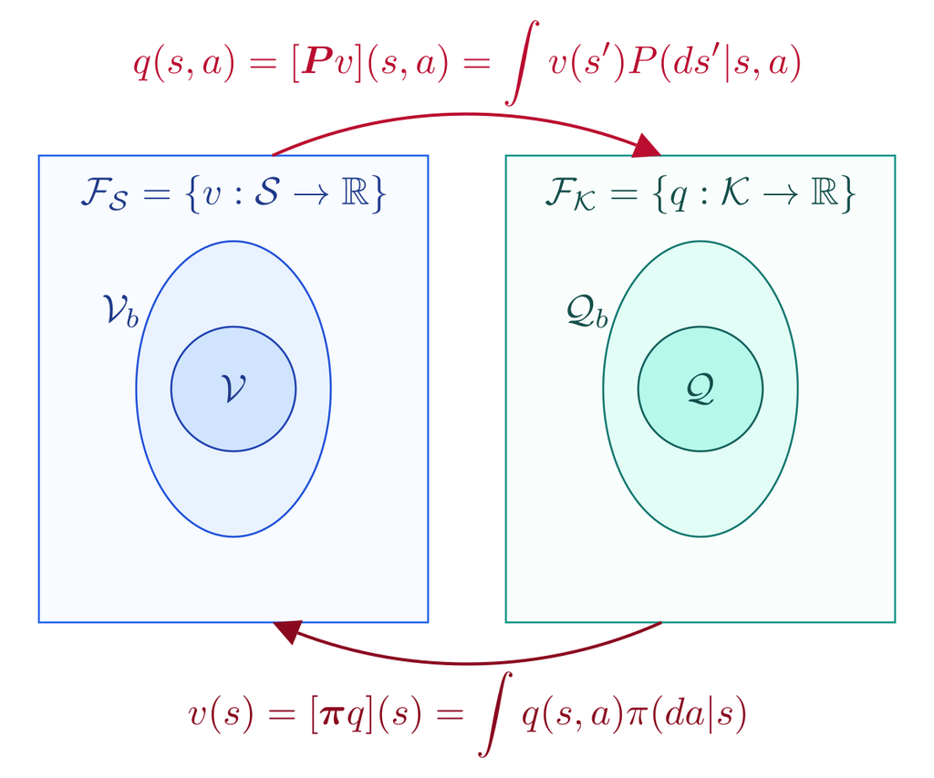

**Key innovation:** decompose the transition into two operators

- $\boldsymbol{P}:\mathcal F_{\mathcal S}\to \mathcal F_{\mathcal K}$ — integrates over next state
  $$[\boldsymbol{P} v](s,a) = \int v(s') P(ds'|s,a)$$
- $\boldsymbol{\pi}:\mathcal F_{\mathcal K}\to \mathcal F_{\mathcal S}$ — integrates over action
  $$[\boldsymbol{\pi }q](s) = \int q(s,a)\pi(da|s)$$

**Composite:** $\boldsymbol{P}_\pi = \boldsymbol{\pi}\boldsymbol{P}:\mathcal F_{\mathcal S}\to\mathcal F_{\mathcal S}$

**Bellman:** $\boldsymbol{T}_\pi v = c_\pi + \gamma \boldsymbol{P}_\pi v$

## Integral Probability Metrics (IPM)

- $\mathcal X$ Polish, weight function $\texttt{w}(x) \ge 1$ for all $x \in \mathcal{X}$
- Weighted norm $\|f\|_{\texttt{w}} = \sup_{x\in\mathcal X} |f(x)|/\texttt{w}(x)$, $\mathcal F_{\texttt{w}}:=\{ f \in \mathcal{M}_{\mathcal X} : \|f\|_{\texttt{w}} < \infty \}$ is a Banach space
- Generator set $\mathfrak{F}\subset\mathcal F_{\textup{\texttt{w}}}$ separates measures. The integral probability metric:

$$\begin{align*}
\textup{\texttt{IPM}}_{\mathfrak{F}} (\mu,\mu') = \sup_{f\in\mathfrak F} \Bigg| \int f d\mu - \int f d\mu'\Bigg|
\end{align*}$$

- Minkowski functional $\varrho_{\mathfrak{F}}:\mathcal F_{\texttt{w}}\to[0,\infty]$ is defined as

$$\begin{align*}
\varrho_{\mathfrak{F}}(f) = \inf\left\{r>0: \frac{f}{r}\in \texttt{absconv}(\mathfrak{F})\right\} \text{ where } \texttt{absconv}(\mathfrak{F}) = \bar{co}(\{\alpha f: f\in \mathfrak{F}, \alpha\in[-1,1]\})
\end{align*}$$

> **Key Result:** For $f$ with finite Minkowski functional:
> $$\begin{align*}
> \Bigg| \int f d\mu - \int f d\mu'\Bigg| \leq \varrho_{\mathfrak{F}}(f) \textup{\texttt{IPM}}_{\mathfrak{F}} (\mu,\mu')
> \end{align*}$$

## Bellman Operators and the Value Iteration Algorithm

Define the composite operator $\boldsymbol{P}_{\pi}:\mathcal F_{\mathcal S}\to \mathcal F_{\mathcal S}$
$$\boldsymbol{P}_{\pi} v(s) = \int \pi(da|s) \int v(s') P(ds'|s,a)$$
which yields the Bellman operator:
$$\boldsymbol{T}_\pi v= c_{\pi}+\gamma \boldsymbol{P}_{\pi} v$$

If $\|\gamma \boldsymbol{P}_\pi\|<1$, then policy evaluation is written as
$$v_\pi = \boldsymbol{T}^\infty_\pi 0 = \sum_{t\geq 0} (\gamma\boldsymbol{P}_{\pi})^t c_{\pi} = \underbrace{\boldsymbol{\sigma}_\pi}_{(\textup{\texttt{id}}_{\mathcal F_{\mathcal S}}- \gamma \boldsymbol{P}_\pi)^{-1}} c_\pi$$

Value iteration algorithm: $v_0 = 0$, $v_{k+1} = \boldsymbol{T} v_k$

> **Lemma:** Under certain reasonable assumptions, if $c\geq 0$, then $\boldsymbol{T}^{k-1} 0 \leq \boldsymbol{T}^k 0 \leq \boldsymbol{T}^k_\pi 0\leq v_\pi$

**Upshot:** $v_k$ is increasing and pointwise bounded by $v_{\pi}$

## Convergence of the Value Iteration Algorithm

**Assumptions**

- $c\in\mathcal Q, c\geq 0$ is inf-compact
- $\Pi_{\textup{\texttt{ss}}}= \{\pi\in\Pi:\textup{\texttt{spec}}(\gamma\boldsymbol{P}_\pi)<1\}$ is nonempty
- $\boldsymbol{P}\mathcal V\subset\mathcal Q$ and $\boldsymbol{\pi }\mathcal Q\subset\mathcal V$ for all $\pi\in\Pi$
- For every $q\in\mathcal Q$ such that $q$ is inf-compact, there exists a $\pi\in\Pi$ such that $\pi(s) \in \mathop{\mathrm{\arg\min}}_{p\in\mathcal P(\mathcal K(s))} \int q(s,a) p(da)$
- The space $\mathcal V$ is closed under bounded increasing limits
- The transition kernel $P$ is continuous with respect to $\textup{\texttt{IPM}}_{\mathfrak{F}_{\mathcal V}}$: $(s_n,a_n)\to (s,a)\implies\lim_{n\to\infty} \textup{\texttt{IPM}}_{\mathfrak{F}_{\mathcal V}}(P(\cdot|s,a),P(\cdot|s_n,a_n)) = 0$

> **Main Theorem:** Value iteration converges to a limit if $v_0 = 0$. The limit is the optimal value function. Greedy policy with respect to the optimal value function is the optimal policy.

Proof mainly follows from Ch 9 in Bertsekas and Shreve (1978) and Feinberg, Kasyanov and Zadoianchuk (2012).

**Key difference from prior work:** No contraction mapping — uses monotone convergence in structured spaces. Subsumes LQG, finite MDPs, Lipschitz MDPs within one framework.

## Comparison with Prior Existence Results

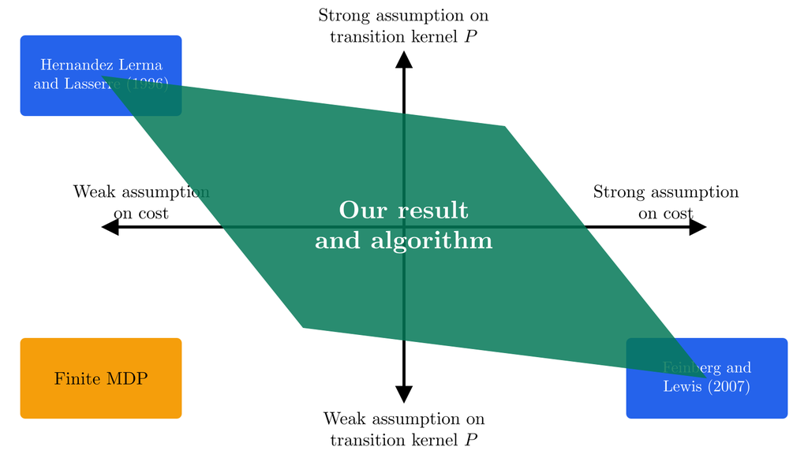

Perturbation Theory for Linear Operators  
→ Policy Gradient Theorem

## A Perturbation Result of Inverse Operators

### The fundamental lemma (Kato, 1966; Atkinson, 2005)

$\boldsymbol{A}, \boldsymbol{B}$ bdd linear operators with $\boldsymbol{A}^{-1}$ bdd $\implies\exists\;\bar\epsilon>0$ such that $\forall\;\epsilon\in[-\bar\epsilon,\bar\epsilon]$:

> **First resolvent identity:**
> $$\begin{align*}
> (\boldsymbol{A}+\epsilon \boldsymbol{B})^{-1} &= \boldsymbol{A}^{-1}-\epsilon (\boldsymbol{A}+\epsilon \boldsymbol{B})^{-1} \boldsymbol{B} \boldsymbol{A}^{-1} = \boldsymbol{A}^{-1}-\epsilon \boldsymbol{A}^{-1}\boldsymbol{B} (\boldsymbol{A}+\epsilon \boldsymbol{B})^{-1}
> \end{align*}$$

> **Second-order expansion:**
> $$\begin{align*}
> (\boldsymbol{A}+\epsilon \boldsymbol{B})^{-1} &= \boldsymbol{A}^{-1}-\epsilon \boldsymbol{A}^{-1}\boldsymbol{B} \boldsymbol{A}^{-1} + \epsilon^2 \boldsymbol{A}^{-1}\boldsymbol{B} (\boldsymbol{A}+\epsilon \boldsymbol{B})^{-1} \boldsymbol{B} \boldsymbol{A}^{-1}
> \end{align*}$$

**Application to MDPs:** Set $\boldsymbol{A} = \textup{\texttt{id}}_{\mathcal F_{\mathcal S}}- \gamma\boldsymbol{P}_\pi$, $\epsilon\boldsymbol{B} = -\gamma\boldsymbol{P}_\Delta$ where $\boldsymbol{P}_\Delta = (\boldsymbol{\pi}' - \boldsymbol{\pi})\boldsymbol{P}$. Then $\boldsymbol{A}^{-1} = \boldsymbol{\sigma}_\pi$ and $(\boldsymbol{A} + \epsilon\boldsymbol{B})^{-1} = \boldsymbol{\sigma}_{\pi'}$.

## Policy Difference Lemma

### Advantage and Policy Advantage Function

- **Advantage function:** $A_\pi = q_\pi - v_\pi$ where $q_\pi = c + \gamma\boldsymbol{P} v_\pi$
- **Policy Advantage Function (PAF)** at $\pi,\pi'\in\Pi_{\textup{\texttt{ss}}}$ from Kakade and Langford (2002):

$$\begin{align*}
PAF_{\pi}(\pi') = \boldsymbol{\sigma}_\pi \boldsymbol{\pi}' A_\pi = \mathop{\mathbb{E}}_{s_t\sim P_\pi(\cdot|s_{t-1})}\left[\sum_{t=0}^\infty \gamma^t[\boldsymbol{\pi}' A_\pi](s_t)\right]
\end{align*}$$

> **Policy Difference Lemma** (via perturbation theory): For $\pi,\pi'\in\Pi_{\textup{\texttt{ss}}}$ with $\boldsymbol{\Delta }=\boldsymbol{\pi}'- \boldsymbol{\pi}$:
> $$\begin{align*}
> v_{\pi'} - v_{\pi} & = PAF_{\pi}(\pi') + \gamma \boldsymbol{\sigma}_\pi \boldsymbol{\Delta}\boldsymbol{P} \boldsymbol{\sigma}_{\pi'} \boldsymbol{\pi}' A_\pi\\
> & = PAF_{\pi}(\pi') + \gamma \boldsymbol{\sigma}_\pi \boldsymbol{\Delta}\boldsymbol{P} \boldsymbol{\sigma}_{\pi} \boldsymbol{\Delta }q_\pi + o(\|\boldsymbol{\Delta}\|^2).
> \end{align*}$$

**Proof sketch:** Apply the resolvent expansion to $\boldsymbol{\sigma}_{\pi'} = (\textup{\texttt{id}}_{\mathcal F_{\mathcal S}}- \gamma\boldsymbol{P}_\pi - \gamma\boldsymbol{P}_\Delta)^{-1}$ and collect first- and second-order terms. The compact operator-theoretic proof replaces page-long algebraic arguments in prior work.

## Gâteaux Derivative of the Value Function

### Directional derivative in policy space

For $\pi, \pi' \in \Pi_{\textup{\texttt{ss}}}$, the Gâteaux derivative of $v_\pi$ in the direction of $\pi'$:
$$\mathfrak{D}_{\pi'}(v_\pi) = \lim_{\epsilon\downarrow 0} \frac{1}{\epsilon}(v_{\pi+\epsilon(\pi'-\pi)} - v_\pi)$$

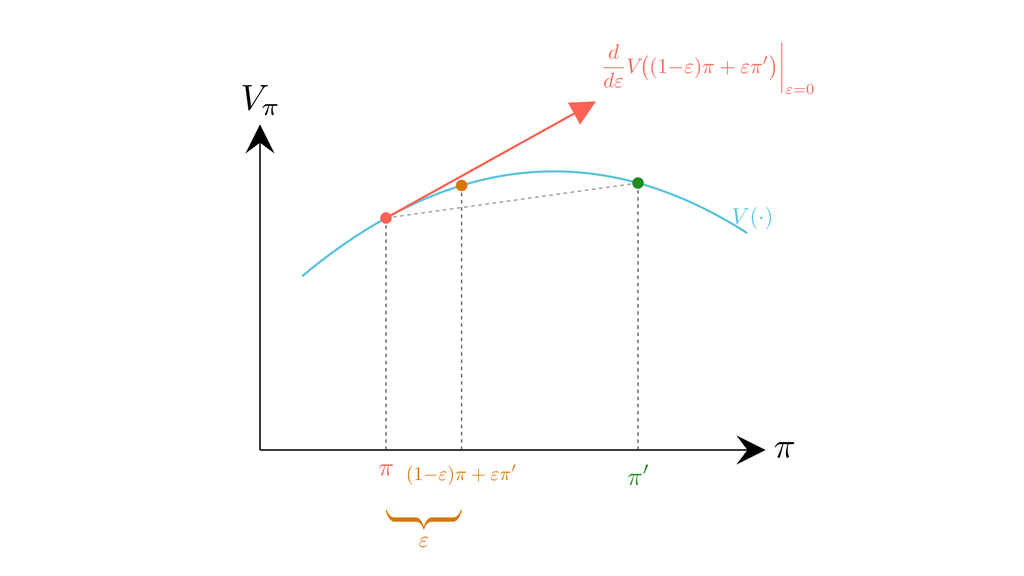

## Gâteaux Derivative of the Value Function

### Directional derivative in policy space

For $\pi, \pi' \in \Pi_{\textup{\texttt{ss}}}$, the Gâteaux derivative of $v_\pi$ in the direction of $\pi'$:
$$\mathfrak{D}_{\pi'}(v_\pi) = \lim_{\epsilon\downarrow 0} \frac{1}{\epsilon}(v_{\pi+\epsilon(\pi'-\pi)} - v_\pi)$$

> **Theorem:** $\mathfrak{D}_{\pi'}(v_\pi) = PAF_\pi(\pi')$

> The **Policy Advantage Function is precisely the Gâteaux derivative** of the value function w.r.t. the policy operator.

### Implications

- Necessary condition for optimality: $\mathfrak{D}_{\pi'}(v_{\pi^*}) = 0$ for all $\pi' \in \Pi_{\textup{\texttt{ss}}}$
- Unifies results from Kakade (2002), Schulman (2015), Ju (2022) in one framework

Policy Gradient + Majorization Minimization  
→ Class of Policy Gradient Methods

## Majorization Bound

- Policy difference lemma implies $v_{\pi'} - v_{\pi} = \underbrace{PAF_{\pi}(\pi')}_{\boldsymbol{\sigma}_\pi \boldsymbol{\pi}' A_\pi} + \gamma \boldsymbol{\sigma}_\pi \boldsymbol{\Delta}\boldsymbol{P} \boldsymbol{\sigma}_{\pi'} \boldsymbol{\Delta }q_\pi$

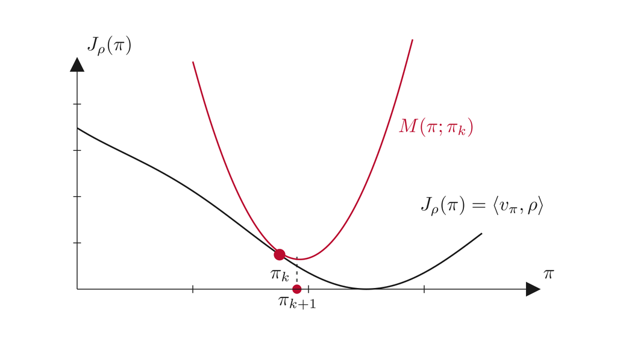

An upper bound on the second-order term:

$$[\boldsymbol{\Delta }\boldsymbol{P} \boldsymbol{\sigma}_{\pi'} \boldsymbol{\Delta }q_\pi](s)
\leq \beta \textup{\texttt{w}}_{\mathcal S}(s) \textup{\texttt{IPM}}_{\Pi,\textup{\texttt{w}}_{\mathcal S}}(\pi,\pi')^2$$

where $\beta = \kappa_{\boldsymbol{P}}\|\boldsymbol{\sigma}_{\pi'}\|\varrho_{\mathfrak{F}_{\mathcal Q}}(q)$ and the **weighted policy metric** is:
$$\textup{\texttt{IPM}}_{\Pi,\textup{\texttt{w}}_{\mathcal S}}(\pi,\pi') = \sup_{s\in\mathcal S} \frac{\textup{\texttt{IPM}}_{\mathfrak{F}_{\mathcal A}(s)} (\pi(\cdot|s), \pi'(\cdot|s))}{\textup{\texttt{w}}_{\mathcal S}(s)}$$

> **Majorization Theorem:**
> $$\begin{align*}
> J_{\pi'}(\rho) - J_{\pi}(\rho) &\leq \left\langle \boldsymbol{\pi}'A_\pi + \beta \textup{\texttt{w}}_{\mathcal S}\textup{\texttt{IPM}}_{\Pi,\textup{\texttt{w}}_{\mathcal S}}(\pi,\pi')^2,\boldsymbol{\sigma}_\pi^*\rho \right\rangle = M(\pi';\pi)
> \end{align*}$$

## IPPO Algorithm

Minimize the majorization bound $\pi_{k+1} = \arg\min_{\pi'} M(\pi';\pi_k)$

> **IPPO Algorithm** (IPM based Policy Optimization): Under T&C
> $$\begin{align*}
> \pi_{k+1}(s)&= \mathop{\mathrm{\arg\min}}_{p\in\mathcal P(\mathcal K(s))} \int A_{\pi_k}(s,a) p(da) + \beta_k \textup{\texttt{IPM}}_{\mathfrak{F}_{\mathcal A}(s)} (\pi_k(s),p)^2 \text{ for all } \underbrace{s\in supp(\boldsymbol{\sigma}_{\pi_k}^*\rho)}_{\textbf{not entire state space}}
> \end{align*}$$

Generalizes TRPO to general MDPs: IPM square is replaced with KL divergence in TRPO
$$\begin{align*}
J_{\pi'}(\rho) - J_{\pi}(\rho) &\leq \left\langle \boldsymbol{\pi}'A_\pi + \beta \:\underbrace{\textup{\texttt{IPM}}_{\mathfrak{F}_{\mathcal A}(s)} (\pi_k(s),\pi'(s))^2}_{\leq D_{KL}(\pi,\pi')},\boldsymbol{\sigma}_{\pi}^*\rho \right\rangle =: M(\pi';\pi)
\end{align*}$$

In PPO, due to estimation error in advantage function, clipping of policy update is used.

## IPPO-MMD Algorithm for Finite MDPs

Define kernel function $\mathfrak{K}_{\mathcal S}(s,s') = \frac{1}{2}Q_{ss'}$ and $\mathfrak{K}_{\mathcal K}((s,a),(s',a')) = \frac{1}{2}(Q_{ss'}+R_{aa'})$ and $\mathfrak{F}_{\mathcal V}$ and $\mathfrak{F}_{\mathcal Q}$ are unit balls in the respective RKHS.

$$\begin{align*}
\textup{\texttt{IPM}}_{\mathfrak{F}_{\mathcal A}(s)} (p_1,p_2)^2 = \frac{1}{2} \big(p_1^T R p_1 + p_2^T R p_2 - 2 p_1^T R p_2\big) \text{ for } p_1,p_2\in \mathcal P(\mathcal A)
\end{align*}$$

### Mirror Descent Formulation:

$$\begin{align*}
\pi_{k+1}(s)&= \mathop{\mathrm{\arg\min}}_{p\in\mathcal P(\mathcal A)}\ \underbrace{A_{\pi_k}(s,\cdot)^T p + \beta_k \textup{\texttt{IPM}}_{\mathfrak{F}_{\mathcal A}(s)} (\pi_k(s),p)^2}_{\text{IPPO Algorithm}} + \underbrace{\frac{1}{\eta_k}D_{KL}(p\|\pi_k(s))}_{\text{Mirror descent}}
\end{align*}$$

> **IPPO-MMD Algorithm**: At each step $k$, run the following for $\bar l$ steps with $p_0=\pi_k(s)$
> $$\begin{align*}
> \vartheta_{k,l}(s,a) &= -\eta_k \Big(A_{\pi_k}(s,a) - \beta_k R_a^T \big(\pi_k(s)-p_l\big)\Big) \tag{clipped}\\
> p_{l+1,a} &= \frac{1}{Z_k(p_l)} p_{l,a} \exp(\vartheta_{k,l}(s,a)),
> \text{ where } Z_k(p_l) = \sum_{a\in\mathcal A} p_{l,a} e^{\vartheta_{k,l}(s,a)}
> \end{align*}$$
> and set $\pi_{k+1}(s) = p_{\bar l}$.

## Simulation Results

### (100 states, 20 actions, branching factor 5, $\gamma=0.9$)

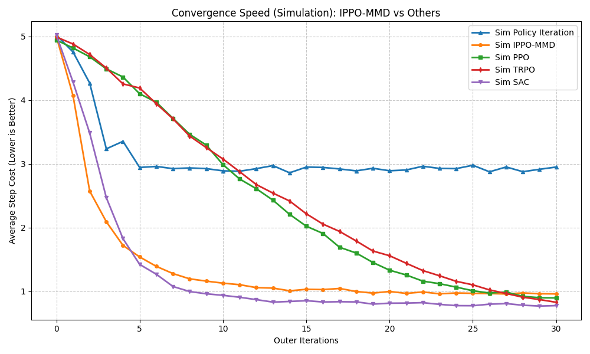

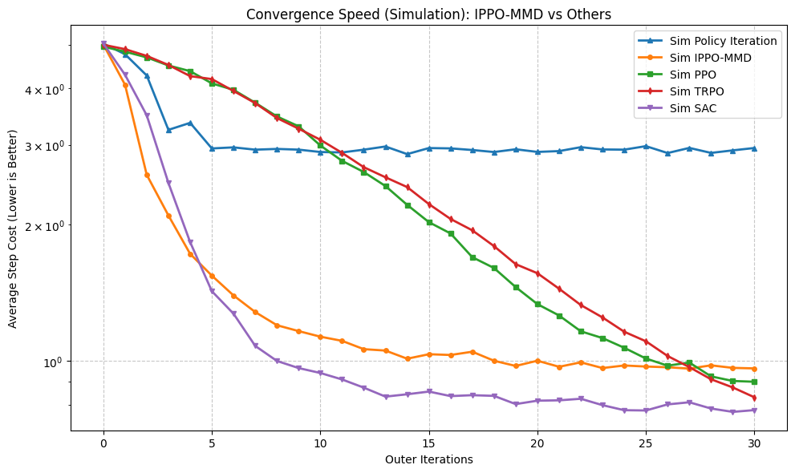

Summary and Future Work  
→ Potential Collaborative Activities

## Summary of Contributions

Step 1

Linear Operator Formulation

- Kernel & policy as **linear operators** over weighted function spaces $\mathcal{F}_{\mathcal{S}}$ and $\mathcal{F}_{\mathcal{K}}$
- Appropriate assumptions $\implies$ can use linear operator theory

Step 2

A New Existence Result

- Monotone convergence, does not invoke contraction mapping
- Uses spectral theory of linear operators
- Unified: subsumes **LQG**, **Finite**, & **Lipschitz**

Step 3

A New Policy Gradient Method: IPPO Algorithm

- Perturbation theory of **linear operators** yields policy gradient
- Majorization bound obtained using integral probability metrics
- Yields **IPPO algorithm** for general MDPs

Step 4

IPPO-MMD Algorithm for finite MDPs

## Future Work

- Solve inverse design problems using **operator learning** and RL
- Derive **sample complexity** guarantees for IPPO and IPPO-MMD by exploiting **dimension independence** in concentration of measures for IPM
- Establish **global optimality**, **convergence properties** and **gradient dominance** for general MDPs

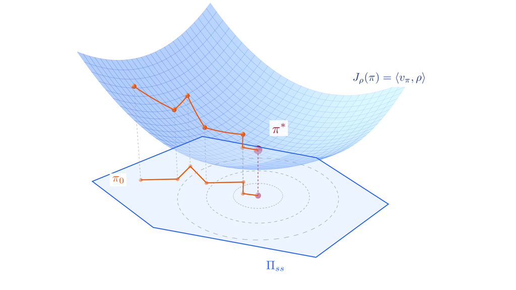

## Seeking collaboration

- Solve complex problems using RL in materials discovery, drug design, robotics, etc.
- Unify different strands of work in statistics, parameter identification, reinforcement learning, and dynamic optimization into **one coherent theory** that can be exploited for **AI for Scientific Discovery**

[figure not shown]